# Wine Quality Prediction — Classification

**Objective:** Train and compare multiple classifiers to predict red wine quality from its physicochemical properties, and determine which is most suitable for deployment.

**Dataset:** `winequality-red.csv` — 1,599 red wine samples, 11 physicochemical features (acidity, sugar, chlorides, sulfur dioxide, density, pH, sulphates, alcohol), and an integer `quality` score from the original UCI Wine Quality dataset.

## 1. Load Data & Inspect Class Distribution

```python
import pandas as pd
import numpy as np
import matplotlib.pyplot as plt
import seaborn as sns
from sklearn.model_selection import train_test_split
from sklearn.preprocessing import StandardScaler
from sklearn.ensemble import RandomForestClassifier
from sklearn.linear_model import SGDClassifier
from sklearn.svm import SVC
from sklearn.metrics import accuracy_score, classification_report, confusion_matrix

sns.set_theme(style="whitegrid", palette="deep")
plt.rcParams['figure.figsize'] = (9, 5)
pd.set_option('display.max_columns', None)

df = pd.read_csv('winequality-red.csv')
print(f"Shape: {df.shape[0]} rows x {df.shape[1]} columns")
df.head()
```

```
Shape: 1599 rows x 12 columns
```

|  | fixed acidity | volatile acidity | citric acid | residual sugar | chlorides | free sulfur dioxide | total sulfur dioxide | density | pH | sulphates | alcohol | quality |
| --- | --- | --- | --- | --- | --- | --- | --- | --- | --- | --- | --- | --- |
| 0 | 7.4 | 0.70 | 0.00 | 1.9 | 0.076 | 11.0 | 34.0 | 0.9978 | 3.51 | 0.56 | 9.4 | 5 |
| 1 | 7.8 | 0.88 | 0.00 | 2.6 | 0.098 | 25.0 | 67.0 | 0.9968 | 3.20 | 0.68 | 9.8 | 5 |
| 2 | 7.8 | 0.76 | 0.04 | 2.3 | 0.092 | 15.0 | 54.0 | 0.9970 | 3.26 | 0.65 | 9.8 | 5 |
| 3 | 11.2 | 0.28 | 0.56 | 1.9 | 0.075 | 17.0 | 60.0 | 0.9980 | 3.16 | 0.58 | 9.8 | 6 |
| 4 | 7.4 | 0.70 | 0.00 | 1.9 | 0.076 | 11.0 | 34.0 | 0.9978 | 3.51 | 0.56 | 9.4 | 5 |

```python
print("Column dtypes:")
print(df.dtypes)
print()
print(f"Missing values: {df.isnull().sum().sum()}")
print(f"Duplicate rows: {df.duplicated().sum()}")
```

```
Column dtypes:
fixed acidity           float64
volatile acidity        float64
citric acid             float64
residual sugar          float64
chlorides               float64
free sulfur dioxide     float64
total sulfur dioxide    float64
density                 float64
pH                      float64
sulphates               float64
alcohol                 float64
quality                   int64
dtype: object

Missing values: 0
Duplicate rows: 240
```

**Observation:** the dataset is fully numeric with no missing values. There ARE duplicate rows (this is a known property of the original UCI dataset, where different samples can share identical measured values by coincidence) — we leave them in, since each row represents an independent wine sample and tasting, not a data-entry artifact.

```python
quality_counts = df['quality'].value_counts().sort_index()
print("Raw quality score distribution (3-8 scale):")
print(quality_counts)
print()
print("As a percentage:")
print((quality_counts / len(df) * 100).round(1))
```

```
Raw quality score distribution (3-8 scale):
quality
3     10
4     53
5    681
6    638
7    199
8     18
Name: count, dtype: int64

As a percentage:
quality
3     0.6
4     3.3
5    42.6
6    39.9
7    12.4
8     1.1
Name: count, dtype: float64
```

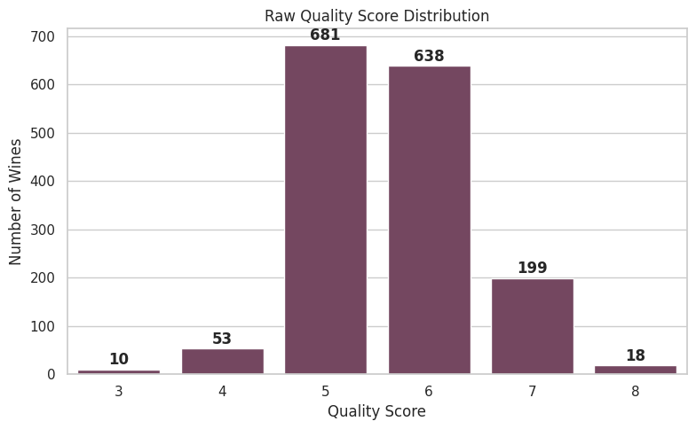

```python
plt.figure(figsize=(8, 5))
sns.barplot(x=quality_counts.index, y=quality_counts.values, color='#7B3F61')
plt.title('Raw Quality Score Distribution')
plt.xlabel('Quality Score')
plt.ylabel('Number of Wines')
for i, v in enumerate(quality_counts.values):
    plt.text(i, v + 10, str(v), ha='center', fontweight='bold')
plt.tight_layout()
plt.show()
```

**Observation:** quality scores 5 and 6 dominate (**82.5%** of all wines combined), while the extremes — score 3 (10 wines, 0.6%) and score 8 (18 wines, 1.1%) — are vanishingly rare. This has direct modelling consequences, discussed in Section 3.

## 2. Exploratory Data Analysis

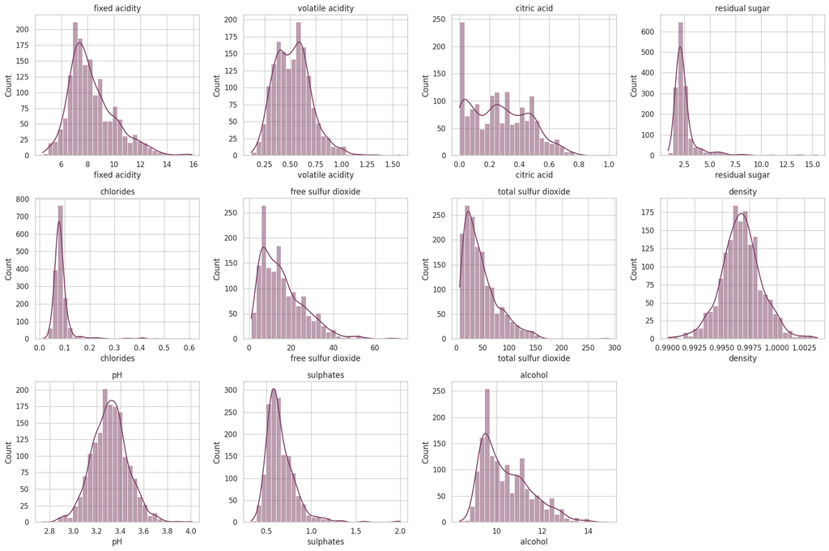

```python
feature_cols = df.columns.drop('quality')

fig, axes = plt.subplots(3, 4, figsize=(18, 12))
axes = axes.flatten()
for i, col in enumerate(feature_cols):
    sns.histplot(df[col], bins=30, kde=True, ax=axes[i], color='#7B3F61')
    axes[i].set_title(col)
axes[-1].axis('off')
plt.tight_layout()
plt.show()
```

**Observation:** most chemical features (`fixed acidity`, `volatile acidity`, `sulphates`, `total sulfur dioxide`, `chlorides`) are **right-skewed with a long tail of high-value outliers** — a small number of wines have unusually high sulfur dioxide or chloride levels. `density` and `pH` are the most symmetric, close-to-normal features, which makes sense chemically since both are tightly regulated by fermentation and acid-base equilibria.

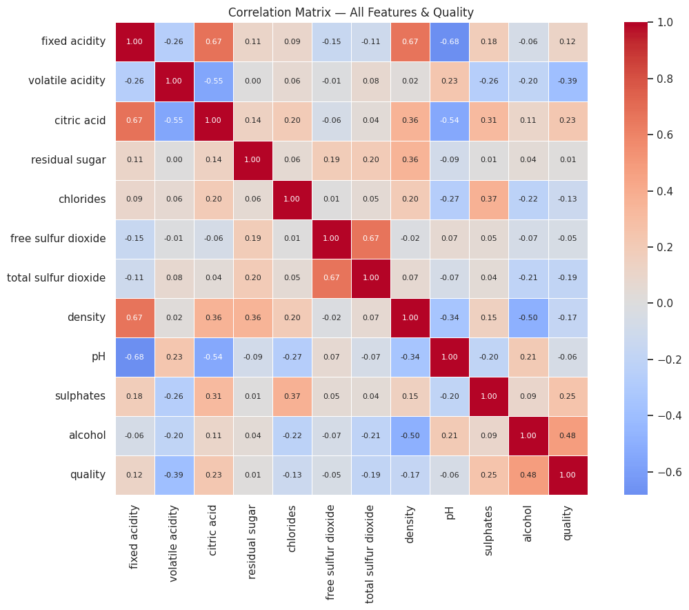

```python
plt.figure(figsize=(12, 9))
corr = df.corr()
sns.heatmap(corr, annot=True, fmt='.2f', cmap='coolwarm', center=0, square=True, linewidths=0.5,
            annot_kws={'size': 8})
plt.title('Correlation Matrix — All Features & Quality')
plt.tight_layout()
plt.show()
```

```python
quality_corr = corr['quality'].drop('quality').sort_values(key=abs, ascending=False)
print("Correlation with quality, ranked by strength:")
quality_corr
```

```
Correlation with quality, ranked by strength:
```

```
alcohol                 0.476166
volatile acidity       -0.390558
sulphates               0.251397
citric acid             0.226373
total sulfur dioxide   -0.185100
density                -0.174919
chlorides              -0.128907
fixed acidity           0.124052
pH                     -0.057731
free sulfur dioxide    -0.050656
residual sugar          0.013732
Name: quality, dtype: float64
```

**Observation:** **`alcohol` (r ≈ 0.48)** is the strongest single correlate of quality — higher-alcohol wines tend to score better. **`volatile acidity` (r ≈ -0.39)** is the strongest negative correlate — this is the acid responsible for a vinegary taste at high concentrations, so it makes intuitive sense that it hurts quality. Most other features show weak correlation (|r| < 0.2) with quality individually, meaning a strong model will likely need to combine several moderate signals rather than rely on one dominant feature (unlike the house price task, where `GrLivArea` alone did most of the work).

## 3. Class Imbalance — Discussion

**Are certain quality scores underrepresented?** Emphatically yes: scores 3 and 8 combined make up only **1.75%** of the data (28 out of 1,599 wines), while scores 5 and 6 make up **82.5%**. This is a severe imbalance across 6 raw classes.

**How does this affect modelling?**

1. **Statistically unreliable evaluation for rare classes.** With only 10 wines scoring 3 in the *entire* dataset, an 80/20 split would leave roughly 2 in the test set — far too few to draw any meaningful conclusion about how well a model predicts that class.
2. **Models will default to the majority classes.** A classifier trained on 6 raw classes has every statistical incentive to never predict 3 or 8 at all, since doing so barely moves overall accuracy but does risk being wrong.
3. **Accuracy becomes a misleading metric on its own** — a model could score ~80%+ accuracy by only ever predicting 5 or 6, while being completely unable to identify genuinely poor or excellent wines, which are arguably the most business-relevant cases to catch.

This motivates the binning decision in Section 4.

## 4. Feature Engineering: Binning Quality into 3 Classes

**Decision: bin the 6 raw scores into 3 ordinal groups** — Low (3-4), Medium (5-6), High (7-8) — rather than predicting the raw 3-8 score directly, and rather than collapsing all the way to a binary good/bad split.

**Why 3 classes instead of 6:** pools the extremely sparse scores (3, 4, 8) with their nearest neighbour so every class has enough samples for the model to learn from and for evaluation to be statistically meaningful.

**Why 3 classes instead of binary (e.g. good ≥ 7 vs. bad < 7):** a binary split would still leave the positive ("good") class at only 13.6% of the data, and would also throw away the useful distinction between a merely mediocre wine and a genuinely poor one — collapsing Low into the same "bad" bucket as Medium loses information that a business user (e.g. a producer trying to catch defective batches) would likely still want. Three ordinal classes keep that structure while still relieving the worst of the sparsity problem.

**Trade-off, stated plainly:** even after binning, Low (63 wines, 3.9%) is still a small minority next to Medium (1,319 wines, 82.5%) — this doesn't eliminate the imbalance, it only makes it survivable for modelling. The results in Section 7 show this trade-off did not fully resolve the problem for the rarest class.

```python
def bucket_quality(q):
    if q <= 4:
        return 'Low'
    elif q <= 6:
        return 'Medium'
    else:
        return 'High'

df['QualityGroup'] = df['quality'].apply(bucket_quality)

group_counts = df['QualityGroup'].value_counts()[['Low', 'Medium', 'High']]
print(group_counts)
print()
print((group_counts / len(df) * 100).round(1))
```

```
QualityGroup
Low         63
Medium    1319
High       217
Name: count, dtype: int64

QualityGroup
Low        3.9
Medium    82.5
High      13.6
Name: count, dtype: float64
```

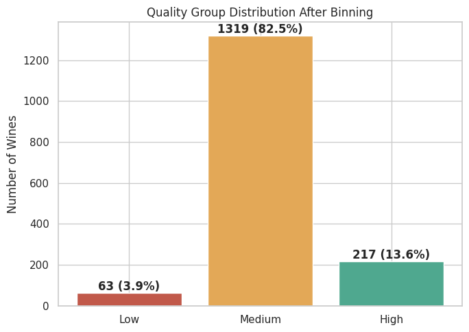

```python
plt.figure(figsize=(7, 5))
colors = ['#C1594A', '#E3A857', '#4FA88F']
plt.bar(group_counts.index, group_counts.values, color=colors)
plt.title('Quality Group Distribution After Binning')
plt.ylabel('Number of Wines')
for i, v in enumerate(group_counts.values):
    plt.text(i, v + 15, f'{v} ({v/len(df)*100:.1f}%)', ha='center', fontweight='bold')
plt.tight_layout()
plt.show()
```

## 5. Stratified Train/Test Split (80/20)

```python
X = df.drop(columns=['quality', 'QualityGroup'])
y = df['QualityGroup']

X_train, X_test, y_train, y_test = train_test_split(
    X, y, test_size=0.2, random_state=42, stratify=y
)

print(f"Training set: {X_train.shape[0]} wines")
print(f"Test set: {X_test.shape[0]} wines")
print()
print("Class ratio preserved by stratification:")
print("Train:", (y_train.value_counts(normalize=True) * 100).round(1).to_dict())
print("Test: ", (y_test.value_counts(normalize=True) * 100).round(1).to_dict())
```

```
Training set: 1279 wines
Test set: 320 wines

Class ratio preserved by stratification:
Train: {'Medium': 82.5, 'High': 13.6, 'Low': 3.9}
Test:  {'Medium': 82.5, 'High': 13.4, 'Low': 4.1}
```

**Observation:** stratification keeps the Low/Medium/High proportions nearly identical between train and test — but note the Low class still only has about 50 training examples and 13 test examples in absolute terms. Stratification preserves the *ratio*, not the *quantity* — it cannot manufacture more Low examples than exist.

```python
scaler = StandardScaler()
X_train_scaled = scaler.fit_transform(X_train)
X_test_scaled = scaler.transform(X_test)
print("Features standardised (zero mean, unit variance) — required for SGD and SVC, and doesn't hurt Random Forest.")
```

```
Features standardised (zero mean, unit variance) — required for SGD and SVC, and doesn't hurt Random Forest.
```

## 6. Training Three Classifiers

- **Random Forest** — an ensemble of decision trees; handles non-linear relationships and feature interactions well, and gives us feature importances "for free."
- **Stochastic Gradient Descent (SGD) Classifier** — a fast linear classifier trained via gradient descent; a good lightweight baseline.
- **Support Vector Classifier (SVC)** — finds the maximum-margin boundary between classes, using an RBF kernel here to capture non-linear boundaries.

```python
rf_model = RandomForestClassifier(n_estimators=200, random_state=42)
rf_model.fit(X_train_scaled, y_train)
rf_pred = rf_model.predict(X_test_scaled)

sgd_model = SGDClassifier(random_state=42, max_iter=1000)
sgd_model.fit(X_train_scaled, y_train)
sgd_pred = sgd_model.predict(X_test_scaled)

svc_model = SVC(kernel='rbf', probability=True, random_state=42)
svc_model.fit(X_train_scaled, y_train)
svc_pred = svc_model.predict(X_test_scaled)

print("All three models trained.")
```

```
All three models trained.
```

## 7. Evaluation

```python
labels_order = ['Low', 'Medium', 'High']

for name, preds in [('Random Forest', rf_pred), ('SGD Classifier', sgd_pred), ('SVC', svc_pred)]:
    acc = accuracy_score(y_test, preds)
    print(f"=== {name} — Accuracy: {acc:.3f} ===")
    print(classification_report(y_test, preds, labels=labels_order, zero_division=0))
    print()
```

```
=== Random Forest — Accuracy: 0.866 ===
              precision    recall  f1-score   support

         Low       0.00      0.00      0.00        13
      Medium       0.88      0.97      0.92       264
        High       0.71      0.51      0.59        43

    accuracy                           0.87       320
   macro avg       0.53      0.49      0.51       320
weighted avg       0.82      0.87      0.84       320


=== SGD Classifier — Accuracy: 0.825 ===
              precision    recall  f1-score   support

         Low       0.00      0.00      0.00        13
      Medium       0.86      0.95      0.90       264
        High       0.52      0.33      0.40        43

    accuracy                           0.82       320
   macro avg       0.46      0.42      0.43       320
weighted avg       0.78      0.82      0.80       320


=== SVC — Accuracy: 0.844 ===
              precision    recall  f1-score   support

         Low       0.00      0.00      0.00        13
      Medium       0.86      0.97      0.91       264
        High       0.64      0.33      0.43        43

    accuracy                           0.84       320
   macro avg       0.50      0.43      0.45       320
weighted avg       0.79      0.84      0.81       320
```

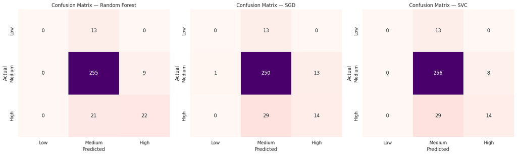

```python
fig, axes = plt.subplots(1, 3, figsize=(18, 5.5))

for ax, (name, preds) in zip(axes, [('Random Forest', rf_pred), ('SGD', sgd_pred), ('SVC', svc_pred)]):
    cm = confusion_matrix(y_test, preds, labels=labels_order)
    sns.heatmap(cm, annot=True, fmt='d', cmap='RdPu', xticklabels=labels_order, yticklabels=labels_order,
                cbar=False, ax=ax)
    ax.set_title(f'Confusion Matrix — {name}')
    ax.set_xlabel('Predicted')
    ax.set_ylabel('Actual')

plt.tight_layout()
plt.show()
```

**Observation — the imbalance problem shows up exactly as predicted in Section 3:** all three confusion matrices show **zero correct predictions for the Low class** — every single Low wine gets misclassified as Medium. With only ~50 training examples that chemically overlap heavily with Medium wines, none of the three models found a usable decision boundary for it. This is the central finding of this analysis: **overall accuracy (82-87%) looks strong, but it's being carried entirely by the Medium class**, and none of these models are currently usable for the (arguably most important) task of flagging a genuinely low-quality wine.

```python
# Does class-weighting rescue the Low class? A quick, honest check.
rf_balanced = RandomForestClassifier(n_estimators=200, random_state=42, class_weight='balanced')
rf_balanced.fit(X_train_scaled, y_train)
rf_balanced_pred = rf_balanced.predict(X_test_scaled)

print(f"Random Forest with class_weight='balanced' — Accuracy: {accuracy_score(y_test, rf_balanced_pred):.3f}")
print(classification_report(y_test, rf_balanced_pred, labels=labels_order, zero_division=0))
```

```
Random Forest with class_weight='balanced' — Accuracy: 0.875
              precision    recall  f1-score   support

         Low       0.00      0.00      0.00        13
      Medium       0.89      0.97      0.93       264
        High       0.75      0.56      0.64        43

    accuracy                           0.88       320
   macro avg       0.55      0.51      0.52       320
weighted avg       0.83      0.88      0.85       320
```

**Observation:** even with `class_weight='balanced'` explicitly re-weighting the loss to compensate for class size, the Low class **still gets zero correct predictions**. This is an important, honest result — it tells us the problem isn't just that the loss function under-weights Low, it's that **there may not be enough distinguishing chemical signal in ~50 training examples** for any of these algorithms to separate Low from Medium. Fixing this would likely require more Low-quality samples (data collection), not just a modelling trick.

## 8. Feature Importance (Random Forest)

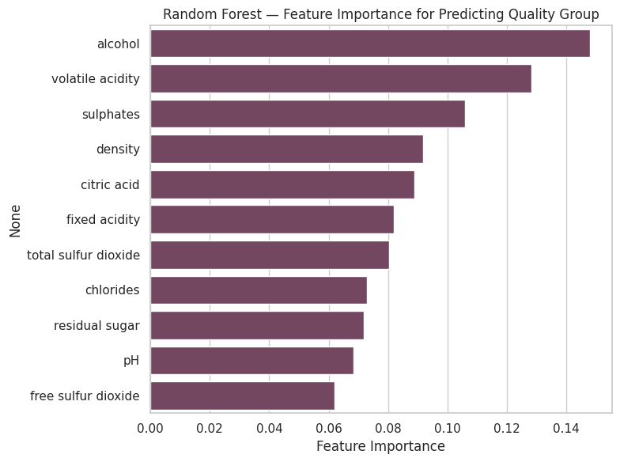

```
alcohol                 0.147945
volatile acidity        0.128305
sulphates               0.105831
density                 0.091750
citric acid             0.088894
fixed acidity           0.081780
total sulfur dioxide    0.080273
chlorides               0.072976
residual sugar          0.071831
pH                      0.068416
free sulfur dioxide     0.062000
dtype: float64
```

```python
importances = pd.Series(rf_model.feature_importances_, index=X.columns).sort_values(ascending=False)

plt.figure(figsize=(8, 6))
sns.barplot(x=importances.values, y=importances.index, color='#7B3F61')
plt.xlabel('Feature Importance')
plt.title('Random Forest — Feature Importance for Predicting Quality Group')
plt.tight_layout()
plt.show()

importances
```

**Observation:** `alcohol` and `volatile acidity` are the two most important features for the Random Forest — matching exactly what the raw correlation analysis in Section 2 already suggested, which is reassuring cross-validation of the two findings against each other. `sulphates` and `density` follow as secondary contributors.

## 9. Model Comparison

```python
from sklearn.metrics import precision_recall_fscore_support

def summarize(name, y_true, y_pred):
    acc = accuracy_score(y_true, y_pred)
    p, r, f1, _ = precision_recall_fscore_support(y_true, y_pred, average='macro', zero_division=0)
    pw, rw, f1w, _ = precision_recall_fscore_support(y_true, y_pred, average='weighted', zero_division=0)
    return {'Model': name, 'Accuracy': acc, 'Macro F1': f1, 'Weighted F1': f1w, 'Macro Recall': r}

comparison = pd.DataFrame([
    summarize('Random Forest', y_test, rf_pred),
    summarize('SGD Classifier', y_test, sgd_pred),
    summarize('SVC', y_test, svc_pred),
]).round(3)

comparison
```

|  | Model | Accuracy | Macro F1 | Weighted F1 | Macro Recall |
| --- | --- | --- | --- | --- | --- |
| 0 | Random Forest | 0.866 | 0.506 | 0.841 | 0.493 |
| 1 | SGD Classifier | 0.825 | 0.433 | 0.796 | 0.424 |
| 2 | SVC | 0.844 | 0.447 | 0.809 | 0.432 |

**Observation:** Random Forest leads on every metric — highest accuracy (0.87), highest macro F1 (0.51, still low because of the Low class), and highest macro recall. The gap between **accuracy** and **macro F1** for every model is the imbalance problem made visible in numbers: accuracy alone would make these models look far better than they actually are at the class-balanced task of identifying all three quality tiers.

## 10. Conclusion

**Which model is most suitable for deployment, and why?** **Random Forest** — it wins on every metric in Section 9 (accuracy, macro F1, weighted F1, macro recall), handles the non-linear relationships between chemical features better than the linear SGD classifier, and — critically for a deployment scenario — provides interpretable feature importances (Section 8) that a wine producer could actually act on (e.g. "watch alcohol content and volatile acidity closely"), which neither SGD nor SVC offer as directly.

**The honest caveat:** none of the three models, including Random Forest, can currently identify a Low-quality wine at all (0% recall on that class, even after class-weighting). Before this model is deployed for any use case where catching low-quality wine matters, **the priority isn't a better algorithm — it's more Low-quality training examples.** With only ~50 such wines in the entire training set, no amount of model tuning is likely to fix this; the bottleneck is data, not modelling choice. As deployed today, this model should be described honestly as **"a Medium vs. High quality classifier with a Low-quality blind spot,"** not as a general-purpose quality predictor.